# Analysis_1st

Ryuta

2026-01-05

# 目的

熱交換器の詰まり本数と各運転パラメータ（U値、ジャケット圧、ポンプ圧）の相関関係を分析し、詰まりの発生要因を特定することを目的とする。

## データ読み込み

### 時系列データ

|  | U | NoS | PI | Flow | Timestamp | Period | production | jacket_P | b/e | pump_outlet |
| --- | --- | --- | --- | --- | --- | --- | --- | --- | --- | --- |
| 1 | 926.877995304464 | 26 | 76.8424467148026 | 2278.63188948368 | 2025-07-01T00:00:00Z | 2502 | 92.84634 | -11.40752 | Beginning | 104.83811779 |
| 2 | 1168.87684613959 | 9 | 76.7301375915099 | 2340.14611456787 | 2023-02-16T00:00:00Z | 2302 | 100.348167 | -15.2118616 | Beginning | 101.39252435 |
| 3 | 443.196894419433 | 18 | 76.3958021151316 | 2282.3485603757 | 2023-09-19T00:00:00Z | 2302 | 0.358204365 | -2.39869857 | End | 104.20442743 |
| 4 | 719.747505236457 | 9 | 76.6794467871711 | 2365.73567407244 | 2023-01-26T00:00:00Z | 2206 | -0.248295471 | -9.874431 | End | 99.7666728 |
| 5 | 1213.71650324032 | 123 | 77.369570682227 | 2368.9824861966 | 2021-10-04T00:00:00Z | 2109 | 116.280258 | -8.057534 | Beginning | 100.24654121 |
| 6 | 8.87547538339535 | 162 | 83.4614743421053 | 2434.91163472381 | 2022-04-13T00:00:00Z | 2109 | 0.02132645 | -1.85208666 | End | 101.2976834279 |
| 7 | 1000.228612502 | 138 | 77.3003813192763 | 2322.94270351492 | 2021-03-13T00:00:00Z | 2103 | 116.466064 | -6.55994129 | Beginning | 102.95150037 |
| 8 | 384.198123770814 | 196 | 77.2130451554507 | 1604.03800410107 | 2021-09-08T00:00:00Z | 2103 | 111.245834 | 14.7946186 | End | 127.6539127 |
| 9 | 1064.24809156946 | 18 | 76.7866123334901 | 2387.45621052123 | 2023-10-21T00:00:00Z | 2310 | 92.33136 | -13.8489895 | Beginning | 98.41412 |
| 10 | 434.17578958972 | 26 | 76.5675439904605 | 2246.53671039443 | 2024-04-12T00:00:00Z | 2310 | -0.004762185 | 1.21759748 | End | 106.117171 |

[output cut: 1447 more lines]

### 詰まりデータ

|  | U | 詰まり本数 | PI | Flow | Timestamp | Period | production | jacket_P | b/e | PeriodType |
| --- | --- | --- | --- | --- | --- | --- | --- | --- | --- | --- |
| 1 | 440.135270717995 | 245 | 76.9620505848158 | 2345.18258233424 | 2013-07-14T00:00:00Z | 1212 | 101.203 |  | End | 1212_End |
| 2 | 447.573656697992 | 304 | 77.0693387210526 | 2346.9675072189 | 2014-03-04T00:00:00Z | 1308 | 102.363808 |  | End | 1308_End |
| 3 | 430.340107094669 | 23 | 76.8997001660724 | 2344.14051480638 | 2016-11-17T00:00:00Z | 1604 | -0.131667346 |  | End | 1604_End |
| 4 | 441.991665318091 | 84 | 77.0122287513158 | 2346.0186730572 | 2017-07-05T00:00:00Z | 1612 | 95.91598 |  | End | 1612_End |
| 5 | 448.519154027179 | 223 | 77.064347131579 | 2346.88469322601 | 2018-03-25T00:00:00Z | 1708 | 95.93339 |  | End | 1708_End |
| 6 | 501.76577295221 | 79 | 77.2585884898026 | 2350.09075198362 | 2019-02-13T00:00:00Z | 1806 | 95.50362 |  | End | 1806_End |
| 7 | 506.214559310089 | 163 | 77.2080859766447 | 2349.2604473802 | 2019-09-16T00:00:00Z | 1903 | 96.21576 |  | End | 1903_End |
| 8 | 440.746498497532 | 264 | 76.9080302676415 | 2344.27993896204 | 2020-04-20T00:00:00Z | 1910 | -0.0361136273 |  | End | 1910_End |
| 9 | 662.445761848089 | 233 | 77.3438414782895 | 2112.58973319581 | 2021-02-02T00:00:00Z | 2011 | 117.520119 | 1.14950156 | End | 2011_End |
| 10 | 384.198123770814 | 196 | 77.2130451554507 | 1604.03800410107 | 2021-09-08T00:00:00Z | 2103 | 111.245834 | 14.7946186 | End | 2103_End |

[output cut: 9 more lines]

## パラメータ推移

各パラメータ（U値、ジャケット圧、ポンプ圧）の推移を時系列グラフで確認する。

### U値

[interactive chart not shown]

### ジャケット圧

[interactive chart not shown]

### ポンプ圧

[interactive chart not shown]

## データ加工と分析

各パラメータ（U値、ジャケット圧、ポンプ圧）について、キャンペーンの初期・末期の最大値を抽出し、詰まり本数（NoS）との相関を分析する。

### Case1) UA

U値の最大値からUAを算出し、相関を確認する。

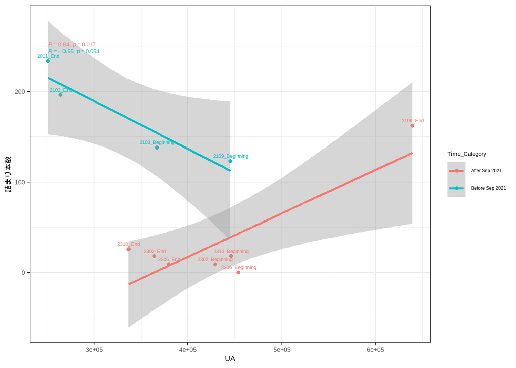

```
##
## Call:
## lm(formula = y_val ~ x_val)
##
## Residuals:
##    Min     1Q Median     3Q    Max
## -79.09 -71.52 -57.78  67.00 122.14
##
## Coefficients:
##               Estimate Std. Error t value Pr(>|t|)
## (Intercept)  1.587e+02  1.094e+02   1.451    0.181
## x_val       -1.860e-04  2.664e-04  -0.698    0.503
##
## Residual standard error: 89.29 on 9 degrees of freedom
## Multiple R-squared:  0.05135,    Adjusted R-squared:  -0.05406
## F-statistic: 0.4871 on 1 and 9 DF,  p-value: 0.5028
```

### Case2) ジャケット圧

ジャケット圧（jacket_P）の最大値と詰まり本数の相関を確認する。

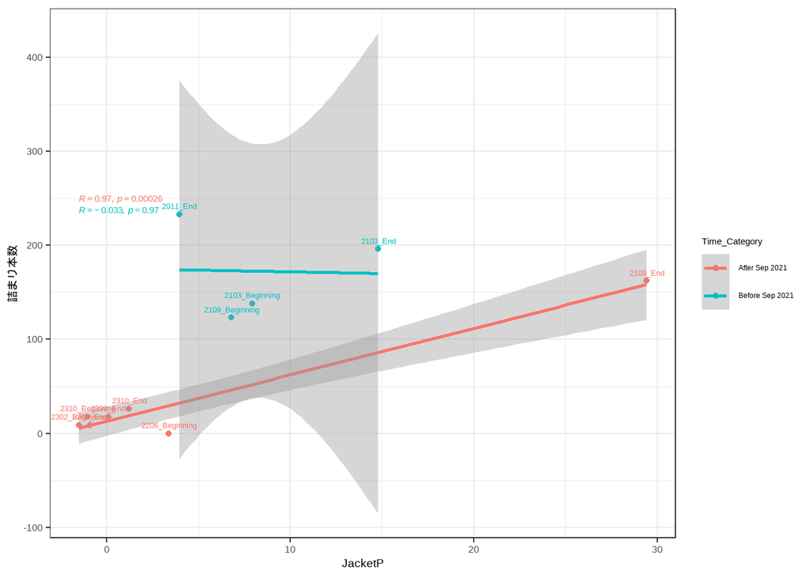

```
##
## Call:
## lm(formula = y_val ~ x_val)
##
## Residuals:
##    Min     1Q Median     3Q    Max
## -70.17 -34.07 -31.31  36.63 159.43
##
## Coefficients:
##             Estimate Std. Error t value Pr(>|t|)
## (Intercept)   50.063     25.673   1.950   0.0830 .
## x_val          5.950      2.431   2.448   0.0369 *
## ---
## Signif. codes:  0 '***' 0.001 '**' 0.01 '*' 0.05 '.' 0.1 ' ' 1
##
## Residual standard error: 71.03 on 9 degrees of freedom
## Multiple R-squared:  0.3997, Adjusted R-squared:  0.333
## F-statistic: 5.993 on 1 and 9 DF,  p-value: 0.03687
```

### Case3) ポンプ圧

ポンプ吐出圧（pump_outlet）の最大値と詰まり本数の相関を確認する。

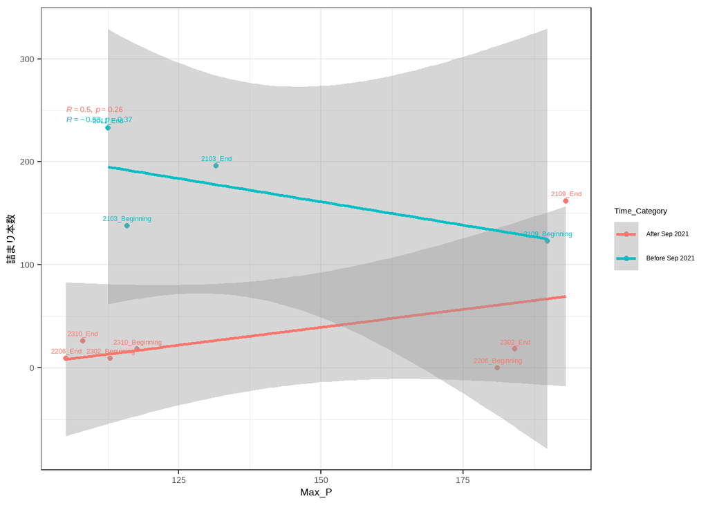

```
##
## Call:
## lm(formula = y_val ~ x_val)
##
## Residuals:
##    Min     1Q Median     3Q    Max
## -88.62 -71.57 -55.51  63.97 151.06
##
## Coefficients:
##             Estimate Std. Error t value Pr(>|t|)
## (Intercept)  70.9859   113.4203   0.626    0.547
## x_val         0.0974     0.7798   0.125    0.903
##
## Residual standard error: 91.6 on 9 degrees of freedom
## Multiple R-squared:  0.001731,   Adjusted R-squared:  -0.1092
## F-statistic: 0.0156 on 1 and 9 DF,  p-value: 0.9033
```

### 乖離幅の分析まとめ

予測式との乖離幅が最も大きいプロットについて、全体本数（922本）に対する割合を以下に示す。

|  | Parameter | Period | Max_Deviation | Percentage_of_Total |
| --- | --- | --- | --- | --- |
| 1 | UA | Before Sep 2021 | 17.78 | 1.93 |
| 2 | UA | After Sep 2021 | 43.35 | 4.7 |
| 3 | Jacket Pressure | Before Sep 2021 | 58.88 | 6.39 |
| 4 | Jacket Pressure | After Sep 2021 | 29.66 | 3.22 |
| 5 | Pump Pressure | Before Sep 2021 | 54.01 | 5.86 |
| 6 | Pump Pressure | After Sep 2021 | 92.72 | 10.06 |